# MA8701 Advanced methods in statistical inference and learning

L3: Shrinkage - algorithm, variants, GLM

Mette Langaas IMF/NTNU

02 February, 2021

# Shrinkage - second act

## Literature L3

- [ELS] The Elements of Statistical Learning: Data Mining, Inference, and Prediction, Second Edition (Springer Series in Statistics, 2009) by Trevor Hastie, Robert Tibshirani, and Jerome Friedman. [Ebook](https://web.stanford.edu/~hastie/Papers/ESLII.pdf). Chapter 4.4.1-4.4.3 (4.4.4 is covered in 3.2 of HTW).
- [HTW] Hastie, Tibshirani, Wainwrigh: “Statistical Learning with Sparsity: The Lasso and Generalizations”. CRC press. [Ebook](https://trevorhastie.github.io/). Chapter 2.4 (understanding from 5.4 will be presented - but not on reading list), 3.1-3.2,3.7 4.1-4.3,4.5-4.6 (but only from a practical view for ch 4)

# Lasso

What do we know from L2?

We forgot to say that

- the acronym is *Least Absolute Shrinkage and Selection Operator*, and that the
- lasso was invented by Robert Tibshirani and published in an article in [JRSSB in 1996](https://www.jstor.org/stable/2346178?seq=1)

We still work on the linear regression case - with continuous response.

## Computations of the lasso solutions

(HTW 2.4)

- Focus is on the Coordinate descent algorithm, where
- soft thresholding plays an important role.
- Also mention the concept of subgradients (from HTW 5.4 - not on the reading list).

See [notes from guest lecturer Benjamin Dunn](https://github.com/mettelang/MA8701V2021/blob/main/Part1/LassoNotesBenDunn.pdf)

**Group discussion:**

Write down in pseudo code the steps of the cyclic coordinate descent algorithm.

## Coordinate descent

(Result HTW page 110): Additive function to minimize:
$$f(\beta)=g(\beta)+\sum_{j=1}^p h_j(\beta_j)$$

$g$ differentiable and convex, $h$ univariate and convex. It is found that the coordinate descent algorithm is *guaranteed to converge* to the global minimizer.

## Generalizations of the lasso penalty

(HTW 4.1-4.3, 4.5-4.6: NB only from a practical point of view)

See [slides from guest lecturer Benjamin Dunn](https://github.com/mettelang/MA8701V2021/blob/main/Part1/LassoandfriendsBenDunn.pdf)

The main goal of this part is to

- know about these special versions of the lasso, and
- to see which practical data situation these can be smart to use.

Maybe one of these is suitable for Data analysis project 1?

Theoretical properties and algorithmic details are not on the reading list.

**Group activity:**

(choose one variant to work with)

For the lasso variants

- the elastic net [HTW 4.2]
- the group lasso [HTW 4.3]
- the fused lasso [HTW 4.5]

write down

- which variation on the classic lasso penalty is used (write down the penalty part of the minimization problem)
- make a drawing of the penalty (comparable to the sphere for ridge and the diamond for lasso)
- in which practical data analysis situation is this variation used (e.g. when many correlated variables are present, when the covariates have a natural group structure, …)
- anything else you found interesting?

# Generalized linear models

(HTW 3.1, 3.2, and TMA4315 GLM background)

## The model

The GLM model has three ingredients:

1. Random component
2. Systematic component
3. Link function

We look into that for the normal and binomial distribution - to get multiple linear regression and logistic regression.

- Write in class
- Poll on standardization and centering.

## Explaining $\beta$ in logistic regression

- The ratio $\frac{P(Y_i=1)}{P(Y_i=0)}=\frac{\pi_i}{1-\pi_1}$ is called the *odds*.
- If $\pi_i=\frac{1}{2}$ then the odds is $1$, and if $\pi_i=\frac{1}{4}$ then the odds is $\frac{1}{3}$. We may make a table for probability vs. odds in R:

| pivec | 0.10 | 0.20 | 0.30 | 0.40 | 0.5 | 0.6 | 0.70 | 0.8 | 0.9 |
| --- | --- | --- | --- | --- | --- | --- | --- | --- | --- |
| odds | 0.11 | 0.25 | 0.43 | 0.67 | 1.0 | 1.5 | 2.33 | 4.0 | 9.0 |

- Odds may be seen to be a better scale than probability to represent chance, and is used in betting. In addition, odds are unbounded above.

We look at the link function (inverse of the response function). Let us assume that our linear predictor has $k$ covariates present

$$\begin{align*}
\eta_i&= \beta_0+\beta_1 x_{i1}+\beta_2 x_{i2}+\cdots + \beta_k x_{ik}\\
\pi_i&= \frac{\exp(\eta_i)}{1+\exp(\eta_i)}\\
\eta_i&=\ln(\frac{\pi_i}{1-\pi_i})\\
\ln(\frac{\pi_i}{1-\pi_i})&=\beta_0+\beta_1 x_{i1}+\beta_2 x_{i2}+\cdots + \beta_k x_{ik}\\
\frac{\pi_i}{1-\pi_i}=&\frac{P(Y_i=1)}{P(Y_i=0)}=\exp(\beta_0)\cdot \exp(\beta_1 x_{i1})\cdots\exp(\beta_k x_{ik})
\end{align*}$$

We have a *multiplicative model* for the odds.

**So, what if we increase $x_{1i}$ to $x_{1i}+1$?**

If the covariate $x_{1i}$ increases by one unit (while all other covariates are kept fixed) then the odds is multiplied by $\exp(\beta_1)$:

$$\begin{align*}
\frac{P(Y_i=1\mid x_{i1}+1)}{P(Y_i=0)\mid x_{i1}+1)}&=\exp(\beta_0)\cdot \exp(\beta_1 (x_{i1}+1))\cdots\exp(\beta_k x_{ik})\\
&=\exp(\beta_0)\cdot \exp(\beta_1 x_{i1})\exp(\beta_1)\cdots\exp(\beta_k x_{ik})\\
&=\frac{P(Y_i=1\mid x_{i1})}{P(Y_i=0\mid x_{i1})}\cdot \exp(\beta_1)\\
\end{align*}$$

This means that if $x_{i1}$ increases by $1$ then: if $\beta_1<0$ we get a decrease in the odds, if $\beta_1=0$ no change, and if $\beta_1>0$ we have an increase. In the logit model $\exp(\beta_1)$ is easier to interpret than $\beta_1$.

The response function as a function of the covariate $x$ and not of $\eta$. Solid lines: $\beta_0=0$ and $\beta_1$ is $0.8$ (blue), $1$ (red) and $2$ (orange), and dashed lines with $\beta_0=1$.

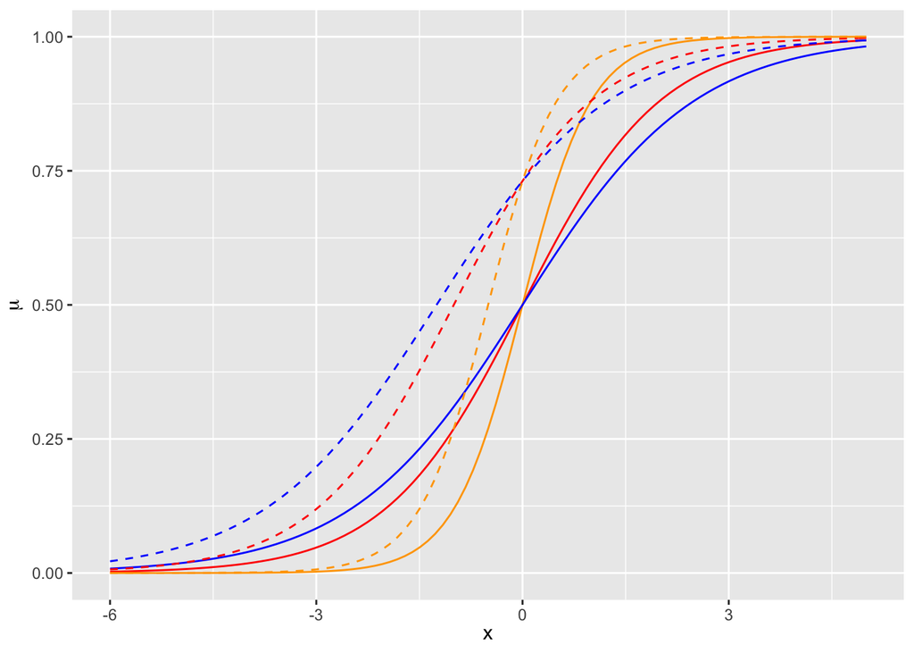

## Parameter estimation

- Maximum likelihood estimation = maximize the likelihood of the data. We write for the loglikelihood ${\cal L}(\beta_0,\beta; {\bf y}, {\bf X})$.
- For penalized method we instead minimize the negative loglikelihood scaled with $\frac{1}{N}$.
- The ridge and lasso penalty is added to the scaled negative loglikelihood.
- We write this out for the normal and binomial distribution.
- Write in class

## Algorithms

- The likelihood for the GLM is differentiable, and the ridge and lasso objective functions are convex - and can be solved with socalled “standard convex optimization methods”.
- But, by popular demand also special algorithms are available - building on the cyclic coordinate descent.

To understand the (ridge and) lasso logistic regression we first look at the *iteratively reweighted least squares* (IRLS) - as a result of the Newton Raphson method.

### Lasso logistic regression fitting algoritm

(HTW page 116)

```r
OUTER LOOP: start with lambdamax and decrement

      MIDDLE LOOP (with warm start)

         compute quadratic approximation Q(beta0,beta)
         for current beta-estimates



              INNER LOOP: cyclic coordinate descent
              to minimize -Q added the lasso penalty
```

### Criteria for choosing $\lambda$

We use cross-validation to choose $\lambda$.

For regression we choose $\lambda$ by minimizing the (mean) squared error.

For (ridge and) lasso logistic regression we may choose:

- misclassification error rate on the validation set
- ROC-AUC
- binomial deviance

### Confusion matrix, sensitivity, specificity

(from TMA4268)

In a two class problem - assume the classes are labelled “-” (non disease,0) and “+” (disease,1). In a population setting we define the following event and associated number of observations.

|  | Predicted - | Predicted + | Total |
| --- | --- | --- | --- |
| True - | True Negative TN | False Positive FP | N |
| True + | False Negative FN | True Positive TP | P |
| Total | N* | P* |  |

(N in this context not to be confused with our sample size…)

**Sensitivity** (recall) is the proportion of correctly classified positive observations: $\frac{\# \text{True Positive}}{\# \text{Condition Positive}}=\frac{\text{TP}}{\text{P}}$.

**Specificity** is the proportion of correctly classified negative observations: $\frac{\# \text{True Negative}}{\# \text{Condition Negative}}=\frac{\text{TN}}{\text{N}}$.

We would like that a classification rule have both a high sensitivity and a high specificity.

Other useful quantities:

| Name | Definition | Synonoms |
| --- | --- | --- |
| False positive rate | FP/N | Type I error, 1-specificity |
| True positive rate | TP/P | 1-Type II error, power, sensitivity, recall |
| Positive predictive value (PPV) | TP/P* | Precision, 1-false discovery proportion |
| Negative predictive value (NPV) | TN/N* |  |

Where the PPV can be used together with the sensitivity to make a precision-recall curve more suitable for low case rates.

### ROC curves

(also from TMA4268)

The receiver operating characteristics (ROC) curve gives a graphical display of the sensitivity against specificity, as the threshold value (cut-off on probability of success or disease) is moved over the range of all possible values. An ideal classifier will give a ROC curve which hugs the top left corner, while a straight line represents a classifier with a random guess of the outcome.

### ROC-AUC

- The **ROC-AUC** score is the area under the ROC curve. It ranges between the values 0 and 1, where a higher value indicates a better classifier.
- The AUC score is useful for comparing the performance of different classifiers, as all possible threshold values are taken into account.
- The ROC-AUC is closely connected to the robust U statistics.
- If the prevalence (case proportion) is very low (0.01ish), the ROC-AUC may be misleading, and the PR-AUC is more commonly used.

### Deviance

The *deviance* is based on the likelihood ratio test statistic.

The derivation assumes that data can be grouped into covariate patterns, with $G$ groups (else interval solutions are used in practice).

**Saturated model:** If we were to provide a perfect fit to our data then we would estimate $\pi_j$ by the observed frequency for the group, $\hat{y}_j=y_j$.

**Candidate model:** the model with the current choice of $\lambda$.

$$D_{\lambda}=2(l(\text{saturated model})-l(\text{candidate model}_{\lambda}))$$
The **null deviance** is replacing the candidate model with a model where $\hat{y}_i=\frac{1}{N}\sum_{i=1}^N y_i$ (the case proportion).

# Example: South African heart disease

(ELS 4.4.2)

**Group discussion:** Comment on what is done and the results. Where are the CIs and $p$-values for the ridge and lasso version?

## Data set

The data is presented in ELS Section 4.4.2, and downloaded from http://statweb.stanford.edu/~tibs/ElemStatLearn.1stEd/ with information in the file `SAheat.info` and data in `SAheart.data`.

- This is a retrospective sample of males in a heart-disease high-risk region in South Africa. *It consists of 462 observations on the 10 variables. All subjects are male in the age range 15-64.
- There are 160 cases (individuals who have suffered from a conorary heart disease) and 302 controls (individuals who have not suffered from a conorary heart disease).
- The overall prevalence in the region was 5.1%.

The response value (`chd`) and covariates

- `chd` : conorary heart disease {yes, no} coded by the numbers {1, 0}
- `sbp` : systolic blood pressure
- `tobacco` : cumulative tobacco (kg)
- `ldl` : low density lipoprotein cholesterol
- `adiposity` : a numeric vector
- `famhist` : family history of heart disease. Categorical variable with two levels: {Absent, Present}.
- `typea` : type-A behavior
- `obesity` : a numerical value
- `alcohol` : current alcohol consumption
- `age` : age at onset

*The goal is to identify important risk factors.*

## Data description

We start by loading and looking at the data:

```r
ds=read.csv("./SAheart.data",sep=",")[,-1]
ds$chd=as.factor(ds$chd)
ds$famhist=as.factor(ds$famhist)
dim(ds)
```

```
## [1] 462  10
```

```r
colnames(ds)
```

```
##  [1] "sbp"       "tobacco"   "ldl"       "adiposity" "famhist"   "typea"
##  [7] "obesity"   "alcohol"   "age"       "chd"
```

```r
head(ds)
```

```
##   sbp tobacco  ldl adiposity famhist typea obesity alcohol age chd
## 1 160   12.00 5.73     23.11 Present    49   25.30   97.20  52   1
## 2 144    0.01 4.41     28.61  Absent    55   28.87    2.06  63   1
## 3 118    0.08 3.48     32.28 Present    52   29.14    3.81  46   0
## 4 170    7.50 6.41     38.03 Present    51   31.99   24.26  58   1
## 5 134   13.60 3.50     27.78 Present    60   25.99   57.34  49   1
## 6 132    6.20 6.47     36.21 Present    62   30.77   14.14  45   0
```

```r
# to be easier to compare with lasso and ridge, we standardize the xs
xs=model.matrix(chd~.,data=ds)[,-1] # to take care of categorical variables, but not include the intercept column
xss=scale(xs)
ys=as.numeric(ds[,10])-1 # not factor, must be numeric else errors...
head(xss)
```

```
##          sbp    tobacco        ldl  adiposity famhistPresent      typea
## 1  1.0574173  1.8210988  0.4778941 -0.2951832      1.1845700 -0.4180170
## 2  0.2767892 -0.7893817 -0.1595071  0.4116942     -0.8423609  0.1931344
## 3 -0.9917313 -0.7741412 -0.6085852  0.8833742      1.1845700 -0.1124413
## 4  1.5453098  0.8413521  0.8062523  1.6223824      1.1845700 -0.2142999
## 5 -0.2111033  2.1694532 -0.5989276  0.3050200      1.1845700  0.7024273
## 6 -0.3086818  0.5583142  0.8352251  1.3884702      1.1845700  0.9061444
##       obesity    alcohol       age
## 1 -0.17659445  3.2741887 0.6286543
## 2  0.67064592 -0.6120811 1.3816170
## 3  0.73472292 -0.5405973 0.2179473
## 4  1.41109128  0.2947424 1.0393612
## 5 -0.01284211  1.6459912 0.4233008
## 6  1.12155816 -0.1186384 0.1494961
```

```r
table(ys)
```

```
## ys
##   0   1
## 302 160
```

```r
dss=data.frame(ys,xss)
colnames(dss)[1]="chd"
apply(dss,2,sd)
```

```
##            chd            sbp        tobacco            ldl      adiposity
##      0.4763125      1.0000000      1.0000000      1.0000000      1.0000000
## famhistPresent          typea        obesity        alcohol            age
##      1.0000000      1.0000000      1.0000000      1.0000000      1.0000000
```

```r
apply(dss,2,mean)
```

```
##            chd            sbp        tobacco            ldl      adiposity
##   3.463203e-01  -1.545836e-16  -3.784382e-17  -8.420712e-17   1.873088e-16
## famhistPresent          typea        obesity        alcohol            age
##  -3.885598e-17  -7.125320e-17  -2.408435e-16   5.629708e-17   1.261817e-17
```

The coloring is done according to the response variable, where green represents a case $Y=1$ and red represents a control $Y=0$.

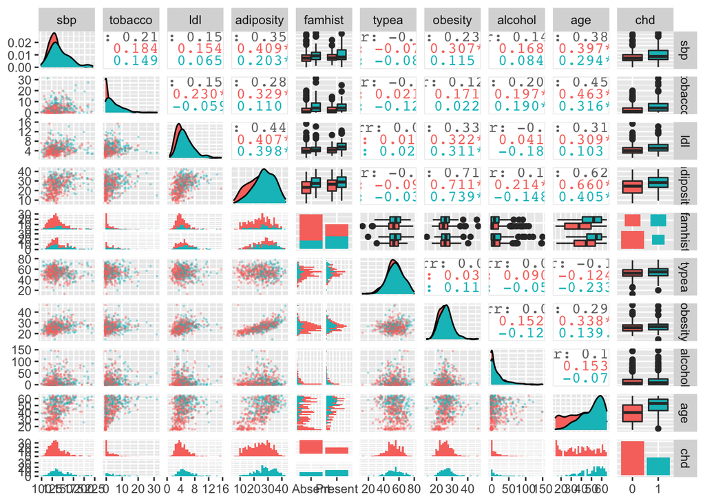

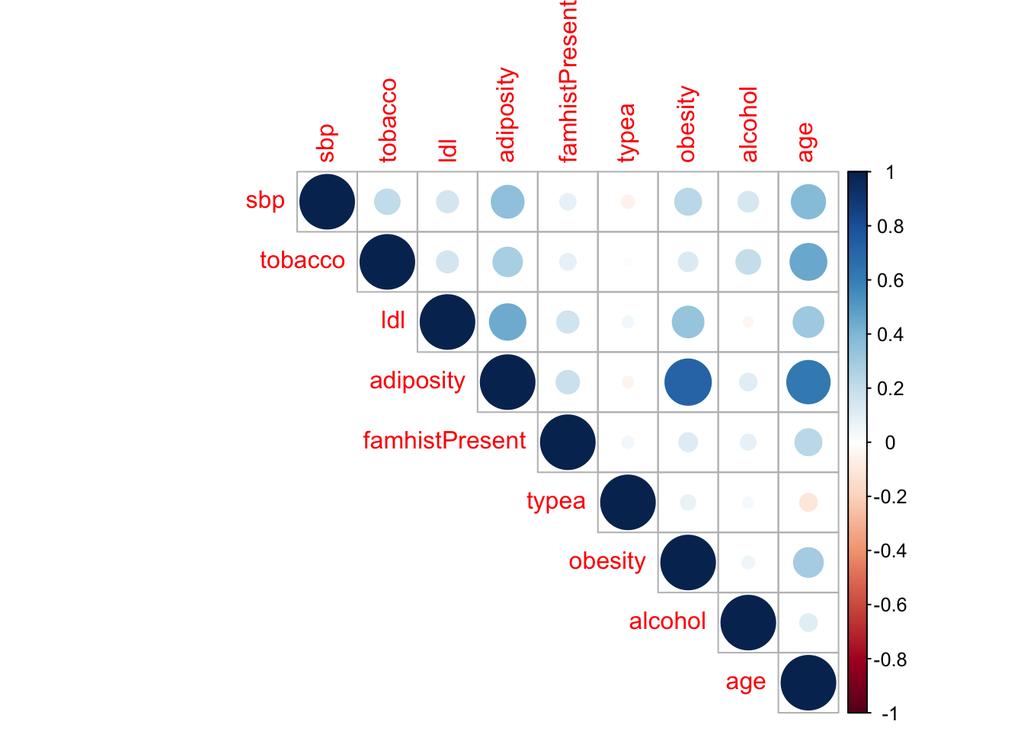

**Q:** Comment on the correlation between covariates, and what that may lead to?

## Logistic regression

We now fit a (multiple) logistic regression model using the `glm` function and the full data set. In order to fit a logistic model, the `family` argument must be set equal to `="binomial"`. The `summary` function prints out the estimates of the coefficients, their standard errors and z-values. As for a linear regression model, the significant coefficients are indicated by stars where the significant codes are included in the `R` printout.

```r
glm_heart = glm(chd~.,data=dss, family="binomial")
summary(glm_heart)
```

```
##
## Call:
## glm(formula = chd ~ ., family = "binomial", data = dss)
##
## Deviance Residuals:
##     Min       1Q   Median       3Q      Max
## -1.7781  -0.8213  -0.4387   0.8889   2.5435
##
## Coefficients:
##                 Estimate Std. Error z value Pr(>|z|)
## (Intercept)    -0.878545   0.123218  -7.130  1.0e-12 ***
## sbp             0.133308   0.117452   1.135 0.256374
## tobacco         0.364578   0.122187   2.984 0.002847 **
## ldl             0.360181   0.123554   2.915 0.003555 **
## adiposity       0.144616   0.227892   0.635 0.525700
## famhistPresent  0.456538   0.112433   4.061  4.9e-05 ***
## typea           0.388726   0.120954   3.214 0.001310 **
## obesity        -0.265082   0.186446  -1.422 0.155095
## alcohol         0.002978   0.109754   0.027 0.978350
## age             0.660695   0.177203   3.728 0.000193 ***
## ---
## Signif. codes:  0 '***' 0.001 '**' 0.01 '*' 0.05 '.' 0.1 ' ' 1
##
## (Dispersion parameter for binomial family taken to be 1)
##
##     Null deviance: 596.11  on 461  degrees of freedom
## Residual deviance: 472.14  on 452  degrees of freedom
## AIC: 492.14
##
## Number of Fisher Scoring iterations: 5
```

```r
exp(coef(glm_heart))
```

```
##    (Intercept)            sbp        tobacco            ldl      adiposity
##      0.4153868      1.1426023      1.4399061      1.4335883      1.1555963
## famhistPresent          typea        obesity        alcohol            age
##      1.5785989      1.4750996      0.7671430      1.0029829      1.9361378
```

A very surprising result here is that `sbp` and `obesity` are NOT significant and `obesity` has negative sign. This is a result of the correlation between covariates. In separate models with only `sbp` or only `obesity` each is positive and significant.

**Q:** How would you interpret the estimated coefficient for `tobacco`?

## Ridge logistic regression

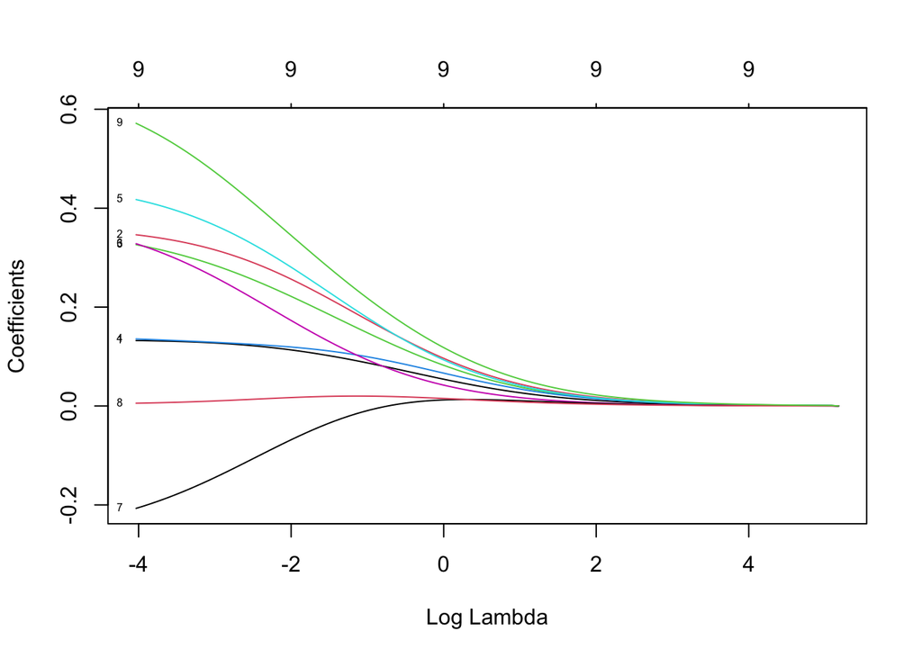

```r
ridgefit=glmnet(x=xss,y=ys,alpha=0,standardize=FALSE,family="binomial") # already standardized
plot(ridgefit,xvar="lambda",label=TRUE)
```

```r
cv.ridge=cv.glmnet(x=xss,y=ys,alpha=0,standardize=FALSE,family="binomial")
print(paste("The lamda giving the smallest CV error",cv.ridge$lambda.min))
```

```
## [1] "The lamda giving the smallest CV error 0.0282259751085414"
```

```r
print(paste("The 1sd err method lambda",cv.ridge$lambda.1se))
```

```
## [1] "The 1sd err method lambda 0.317069161222362"
```

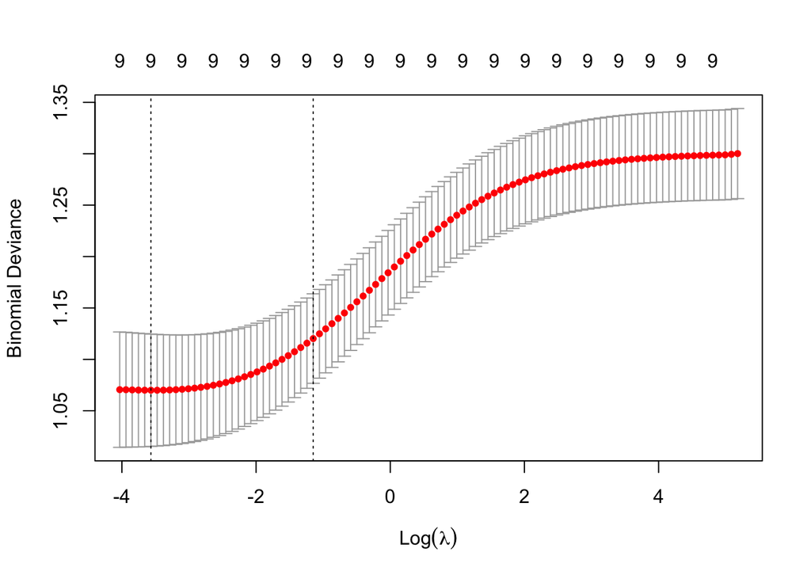

```r
plot(cv.ridge)
```

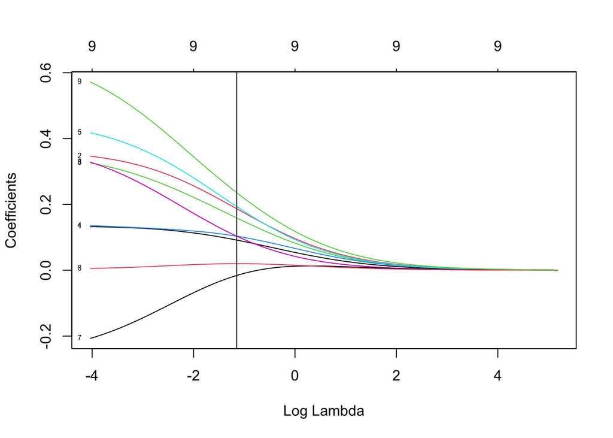

```r
# use 1sd error rule default
plot(ridgefit,xvar="lambda",label=TRUE);
abline(v=log(cv.ridge$lambda.1se));
```

```r
print(cbind(coef(ridgefit,s=cv.ridge$lambda.1se),coef(glm_heart)))
```

```
## 10 x 2 sparse Matrix of class "dgCMatrix"
##                          1
## (Intercept)    -0.69323989 -0.878545196
## sbp             0.09170132  0.133308398
## tobacco         0.18688333  0.364577926
## ldl             0.15887370  0.360180594
## adiposity       0.10341856  0.144616485
## famhistPresent  0.19348746  0.456537713
## typea           0.10349562  0.388725509
## obesity        -0.01578297 -0.265082072
## alcohol         0.02004894  0.002978424
## age             0.23560015  0.660695163
```

```r
# now possible to compare since the glm was also on standardized variables
```

## Lasso logistic regression

Numbering in plots is order of covariates, so:

```r
cbind(1:9,colnames(xss))
```

```
##       [,1] [,2]
##  [1,] "1"  "sbp"
##  [2,] "2"  "tobacco"
##  [3,] "3"  "ldl"
##  [4,] "4"  "adiposity"
##  [5,] "5"  "famhistPresent"
##  [6,] "6"  "typea"
##  [7,] "7"  "obesity"
##  [8,] "8"  "alcohol"
##  [9,] "9"  "age"
```

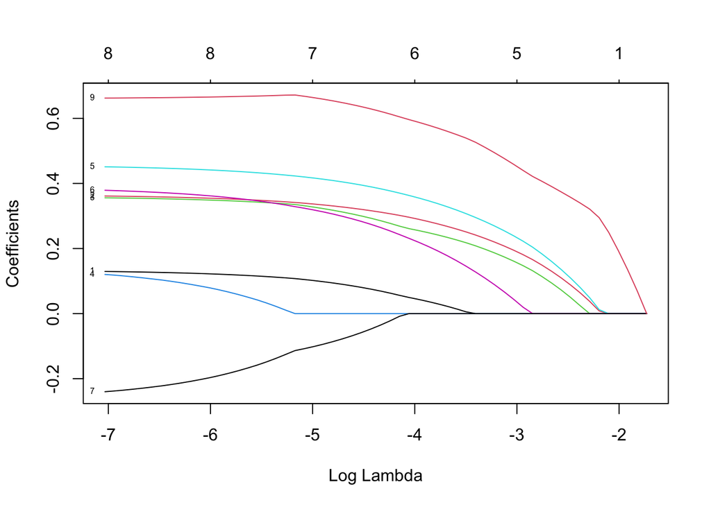

```r
lassofit=glmnet(x=xss,y=ys,alpha=1,standardize=FALSE,family="binomial") # already standardized
plot(lassofit,xvar="lambda",label=TRUE)
```

```r
cv.lasso=cv.glmnet(x=xss,y=ys,alpha=1,standardize=FALSE,,family="binomial")
print(paste("The lamda giving the smallest CV error",cv.lasso$lambda.min))
```

```
## [1] "The lamda giving the smallest CV error 0.0143787011970972"
```

```r
print(paste("The 1sd err method lambda",cv.lasso$lambda.1se))
```

```
## [1] "The 1sd err method lambda 0.0528903235644135"
```

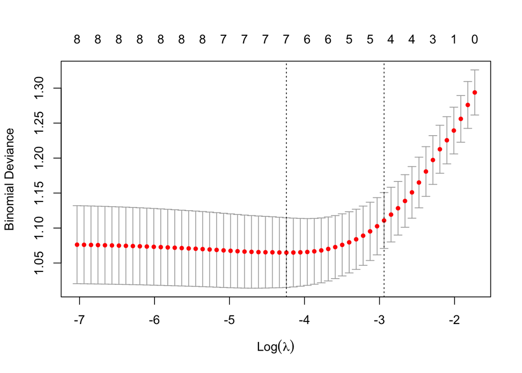

```r
plot(cv.lasso)
```

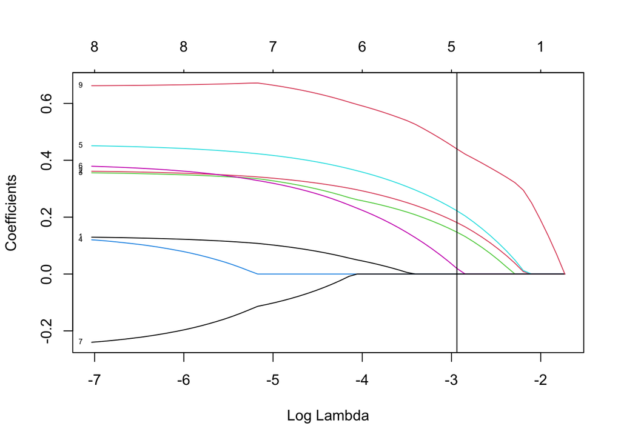

```r
# use 1sd error rule default
plot(lassofit,xvar="lambda",label=TRUE);
abline(v=log(cv.lasso$lambda.1se));
```

```r
resmat=cbind(coef(lassofit,s=cv.lasso$lambda.1se),coef(ridgefit,s=cv.ridge$lambda.1se),coef(glm_heart))
colnames(resmat)=c("lasso logistic","ridge logistic","logistic")
print(resmat)
```

```
## 10 x 3 sparse Matrix of class "dgCMatrix"
##                lasso logistic ridge logistic     logistic
## (Intercept)       -0.70977228    -0.69323989 -0.878545196
## sbp                .              0.09170132  0.133308398
## tobacco            0.18103811     0.18688333  0.364577926
## ldl                0.14726886     0.15887370  0.360180594
## adiposity          .              0.10341856  0.144616485
## famhistPresent     0.22246385     0.19348746  0.456537713
## typea              0.01954765     0.10349562  0.388725509
## obesity            .             -0.01578297 -0.265082072
## alcohol            .              0.02004894  0.002978424
## age                0.43990121     0.23560015  0.660695163
```

# Computational details for the glmnet implementation

(HTW 3.7)

`glmnet` is the implementation in R of the elastic net from HTW-book, and the package is maintained by Trevor Hastie.

The package fits generalized linear models using penalized maximum likelihood of elastic net type (lasso and ridge are special cases).

The logistic lasso is fitted using a quadratic approximation for the negative log-likelihood in a “proximal-Newton iterative approach”.

## Software links

- [R glmnet on CRAN](https://cran.r-project.org/web/packages/glmnet/index.html) with [resources](http://www.stanford.edu/~hastie/glmnet).
  - [Getting started](https://glmnet.stanford.edu/articles/glmnet.html)
  - [GLM with glmnet](https://glmnet.stanford.edu/articles/glmnetFamily.html)

For Python there are different options.

- [Python glmnet](https://web.stanford.edu/~hastie/glmnet_python/) is recommended by Hastie et al.
- [scikit-learn](https://scikit-learn.org/stable/modules/linear_model.html#ridge-regression-and-classification) (seems to mostly be for regression? is there lasso for classification here?)

## glmnet inputs

```r
glmnet(x, y,
 family = c("gaussian", "binomial", "poisson", "multinomial","cox", "mgaussian"),
 weights = NULL, offset = NULL, alpha = 1, nlambda = 100,
 lambda.min.ratio = ifelse(nobs < nvars, 0.01, 1e-04),
 lambda = NULL, standardize = TRUE, intercept = TRUE,
 thresh = 1e-07, dfmax = nvars + 1,
 pmax = min(dfmax * 2 + 20, nvars),
 exclude = NULL, penalty.factor = rep(1, nvars),
 lower.limits = -Inf, upper.limits = Inf, maxit = 1e+05,
 type.gaussian = ifelse(nvars < 500, "covariance", "naive"),
 type.logistic = c("Newton", "modified.Newton"),
 standardize.response = FALSE,
 type.multinomial = c("ungrouped","grouped"),
 relax = FALSE, trace.it = 0, ...)
```

## cv.glmnet inputs

```r
cv.glmnet(x, y, weights = NULL, offset = NULL, lambda = NULL,
  type.measure = c("default", "mse", "deviance", "class", "auc", "mae","C"),
  nfolds = 10, foldid = NULL,
  alignment = c("lambda", "fraction"), grouped = TRUE,
  keep = FALSE, parallel = FALSE,
  gamma = c(0, 0.25, 0.5, 0.75, 1), relax = FALSE, trace.it = 0, ...)
```

type.measure defaults to deviance (accoring to help(cv.glmnet)). The last is for Cox models.

### Family

we have only covered `gaussian` (the default) and `binomial`.

Each family has implemented the deviance measure. Poisson regression and Cox proportional hazard (survival analysis) is also implemented in glmnet.

### Penalties

The elastic net is implemented, with three possible adjustment parameters.

$$\text{minimize}_{\beta_0,\beta} \{ -\frac{1}{N} l(y;\beta_0,\beta)+\lambda \sum_{j=1}^p
\gamma_j ((1-\alpha)\beta_j^2+\alpha \lvert \beta_j \rvert)\}$$

- $\lambda$: the penalty, default a grid of 100 values is chosen, to cover the lasso path on the log scale.
- $\alpha$: elastic net parameter $\in [0,1]$. This is usually manually selected by a grid search over 3-5 values. Default is $\alpha=1$ (lasso), and with $\alpha=0$ we get ridge.
- $\gamma_j$: penalty modifier for each covariate to be able to always include ($\gamma_j==0$), or exclude ($\gamma_j=\text{Inf}$), or give individual penalty modifications. Default $\lambda_j=1$.

For the $\lambda$ penalty the maximal value is for

- linear regression: $\lambda_{\text max}=\text{max}_j \lvert \hat{\beta}_{LS,j} \rvert$ (standardized coefficients) or, should there also be a factor 1/N?
- logistic regression: $\lambda_{\text max}=\text{max}_{j}\lvert {\bf x}_j ^T ({\bf y}-\bar{p}) \rvert$ where $\bar p$ is the mean case rate.

### Additional modifications

- Coefficient bounds can be set (possible since coordinate descent is used)
- Some coefficients can be excluded from the penalization (than thus forced in).
- Offset can be added (popular if rate models for Poisson is used)
- For binary and multinomial data factors or matrices can be input.
- Sparse matrices with covariates can be supplied.

## Lasso variants

Elastic net is already in glmnet (alpha-parameter).

Other lasso variants have their own R packages:

- The group lasso https://cran.r-project.org/web/packages/grplasso/grplasso.pdf
- The fused lasso https://cran.r-project.org/web/packages/genlasso/genlasso.pdf
- Bayesian lasso blasso function for normal data in package monomvn https://rdrr.io/cran/monomvn/man/monomvn-package.html
- Elastic net for ordinal data: https://cran.r-project.org/web/packages/ordinalNet/ordinalNet.pdf

# Exercises

This week the best way to spend the time is to work on the Data Analysis Project 1.

But, also good to study the R-code for the South African heart disease example, and make some changes.

**Smart:** save this file as an .Rmd file and then run `purl(file.Rmd)` to produce a file with only the R-commands. (At the html-version you choose Code-Download Rmd on the top of the file).

- Change the CV criterion to auc and to class. Are there changes to what is the best choice for $\lambda$?

# References

- Robert Tibshirani Regression Shrinkage and Selection via the Lasso, Journal of the Royal Statistical Society. Series B (Methodological) Vol. 58, No. 1 (1996), pp. 267-288 (22 pages)
- [Lecture notes on ridge regression: Wessel N. van Wieringen](https://arxiv.org/pdf/1509.09169.pdf)